# Bike Sharing Demand

```python
import pandas as pd
```

```python
from google.colab import drive
drive.mount('/content/drive', force_remount=True)
```

```python
# Load the data into a pandas DataFrame
data = pd.read_csv("train_bike.csv", sep=None, engine='python')


# Display the first few rows of the DataFrame
data.shape
```

```
(10886, 12)
```

## Data Overview

https://www.kaggle.com/competitions/bike-sharing-demand/overview

provided are hourly rental data spanning two years. We will use data from the first two weeks of the month to predict the next day. We must predict the total count of bikes rented during each hour covered by the test set, using only information available prior to the rental period.

**Data Fields**

datetime: hourly date + timestamp

season: 1 = spring, 2 = summer, 3 = fall, 4 = winter

holiday: whether the day is considered a holiday

workingday: whether the day is neither a weekend nor holiday

weather:

- 1: Clear, Few clouds, Partly cloudy, Partly cloudy
- 2: Mist + Cloudy, Mist + Broken clouds, Mist + Few clouds, Mist
- 3: Light Snow, Light Rain + Thunderstorm + Scattered clouds, Light Rain + Scattered clouds
- 4: Heavy Rain + Ice Pallets + Thunderstorm + Mist, Snow + Fog

temp: temperature in Celsius

atemp: "feels like" temperature in Celsius

humidity: relative humidity

windspeed: wind speed

casual: number of non-registered user rentals initiated

registered: number of registered user rentals initiated

count: number of total rentals

```python
data.head()
```

|  | datetime | season | holiday | workingday | weather | temp | atemp | humidity | windspeed | casual | registered | count |
| --- | --- | --- | --- | --- | --- | --- | --- | --- | --- | --- | --- | --- |
| 0 | 2011-01-01 00:00:00 | 1 | 0 | 0 | 1 | 9.84 | 14.395 | 81 | 0.0 | 3 | 13 | 16 |
| 1 | 2011-01-01 01:00:00 | 1 | 0 | 0 | 1 | 9.02 | 13.635 | 80 | 0.0 | 8 | 32 | 40 |
| 2 | 2011-01-01 02:00:00 | 1 | 0 | 0 | 1 | 9.02 | 13.635 | 80 | 0.0 | 5 | 27 | 32 |
| 3 | 2011-01-01 03:00:00 | 1 | 0 | 0 | 1 | 9.84 | 14.395 | 75 | 0.0 | 3 | 10 | 13 |
| 4 | 2011-01-01 04:00:00 | 1 | 0 | 0 | 1 | 9.84 | 14.395 | 75 | 0.0 | 0 | 1 | 1 |

```python
data.info()
```

```
<class 'pandas.core.frame.DataFrame'>
RangeIndex: 10886 entries, 0 to 10885
Data columns (total 12 columns):
 #   Column      Non-Null Count  Dtype
---  ------      --------------  -----
 0   datetime    10886 non-null  object
 1   season      10886 non-null  int64
 2   holiday     10886 non-null  int64
 3   workingday  10886 non-null  int64
 4   weather     10886 non-null  int64
 5   temp        10886 non-null  float64
 6   atemp       10886 non-null  float64
 7   humidity    10886 non-null  int64
 8   windspeed   10886 non-null  float64
 9   casual      10886 non-null  int64
 10  registered  10886 non-null  int64
 11  count       10886 non-null  int64
dtypes: float64(3), int64(8), object(1)
memory usage: 1020.7+ KB
```

## EDA

```python
import matplotlib.pyplot as plt
import seaborn as sns
```

```python
# First, we have to convert the type of this column
data["datetime"] = pd.to_datetime(data["datetime"])

# Then we can create some more granular features related to time
data["hour"] = data["datetime"].dt.hour
data["day_of_week"] = data["datetime"].dt.dayofweek
data["month"] = data["datetime"].dt.month
data["year"] = data["datetime"].dt.year
data["day_of_month"] = data["datetime"].dt.day
```

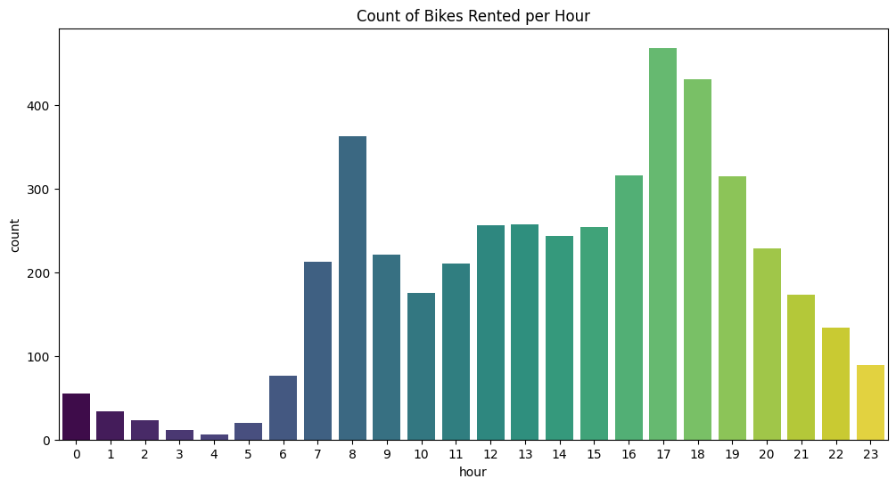

```python
plt.figure(figsize=(12,6))
sns.barplot(x='hour', y='count', data=data.groupby('hour')['count'].mean().reset_index(), hue='hour', legend=False, palette='viridis')
plt.title('Count of Bikes Rented per Hour')
plt.show()
```

```python
# rather than repeating the plot code, let's make a function
def plot_bike_counts(feature: str):
  plt.figure(figsize=(12,6))
  sns.barplot(x=feature, y='count', data=data.groupby(feature)['count'].mean().reset_index(), hue=feature, legend=False, palette='viridis')
  title_feature = feature.replace('_', ' ').title()
  plt.title(f'Count of Bikes Rented per {title_feature}')
  plt.show()
```

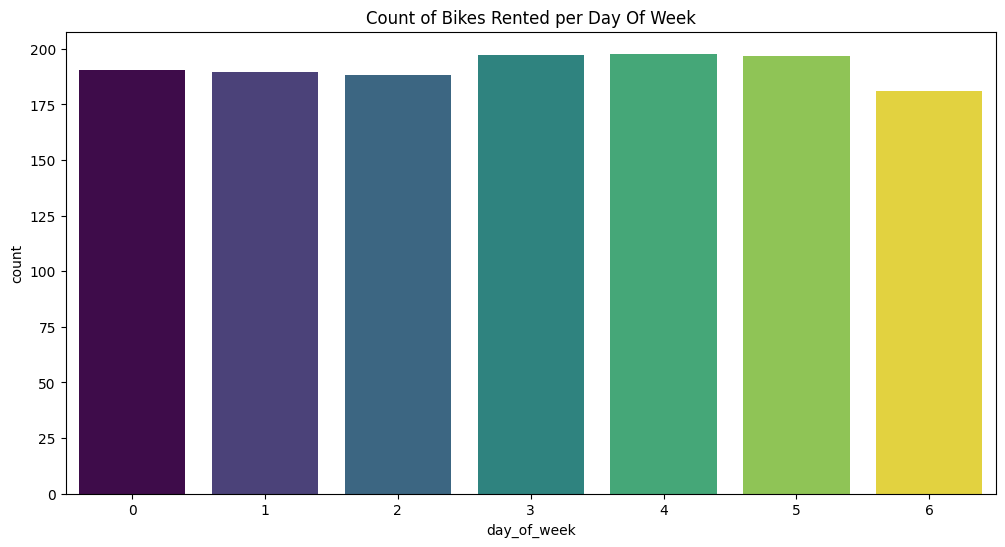

```python
plot_bike_counts('day_of_week')
```

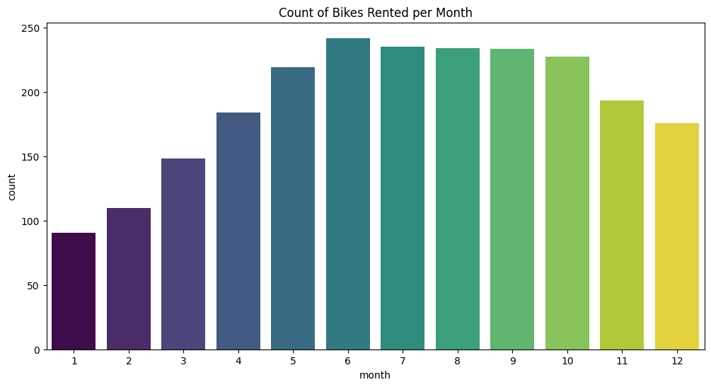

```python
plot_bike_counts('month')
```

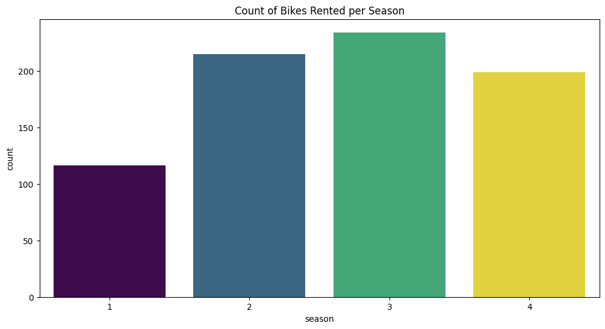

```python
plot_bike_counts('season')
```

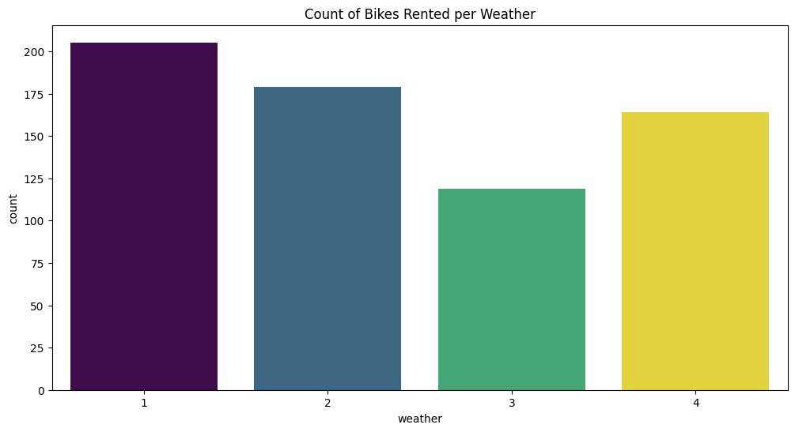

```python
plot_bike_counts('weather')
```

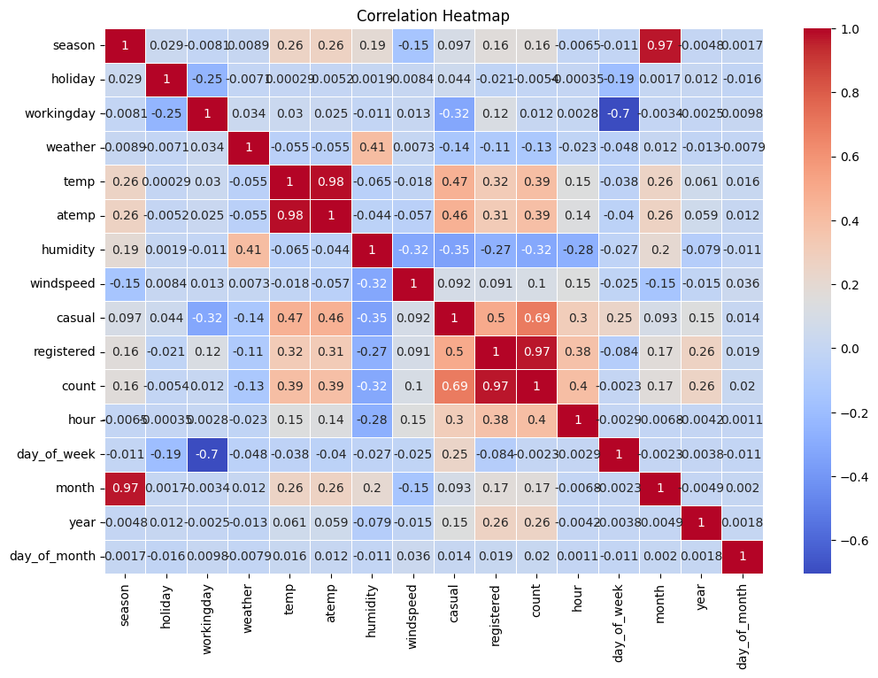

```python
plt.figure(figsize=(12,8))
sns.heatmap(data.corr(numeric_only=True), annot=True, cmap='coolwarm', linewidths=.5)
plt.title('Correlation Heatmap')
plt.show()
```

```python
# Let's check for NULLs
data.isna().sum()
```

|  | 0 |
| --- | --- |
| datetime | 0 |
| season | 0 |
| holiday | 0 |
| workingday | 0 |
| weather | 0 |
| temp | 0 |
| atemp | 0 |
| humidity | 0 |
| windspeed | 0 |
| casual | 0 |
| registered | 0 |
| count | 0 |
| hour | 0 |
| day_of_week | 0 |
| month | 0 |
| year | 0 |
| day_of_month | 0 |

**dtype:** int64

## Data Prep

### Train-test Split

```python
train_data = data.loc[data['day_of_month'] <= 15]
test_data = data.loc[data['day_of_month'] == 16]
```

```python
len(train_data), len(test_data)
```

```
(8600, 574)
```

### Define features and target

```python
y_train = train_data['count']

cols_to_drop = ['datetime', 'casual', 'registered', 'count']
train_features = train_data.drop(columns=cols_to_drop)
```

```python
train_features.head()
```

|  | season | holiday | workingday | weather | temp | atemp | humidity | windspeed | hour | day_of_week | month | year | day_of_month |
| --- | --- | --- | --- | --- | --- | --- | --- | --- | --- | --- | --- | --- | --- |
| 0 | 1 | 0 | 0 | 1 | 9.84 | 14.395 | 81 | 0.0 | 0 | 5 | 1 | 2011 | 1 |
| 1 | 1 | 0 | 0 | 1 | 9.02 | 13.635 | 80 | 0.0 | 1 | 5 | 1 | 2011 | 1 |
| 2 | 1 | 0 | 0 | 1 | 9.02 | 13.635 | 80 | 0.0 | 2 | 5 | 1 | 2011 | 1 |
| 3 | 1 | 0 | 0 | 1 | 9.84 | 14.395 | 75 | 0.0 | 3 | 5 | 1 | 2011 | 1 |
| 4 | 1 | 0 | 0 | 1 | 9.84 | 14.395 | 75 | 0.0 | 4 | 5 | 1 | 2011 | 1 |

```python
y_test = test_data['count']
test_features = test_data.drop(columns=cols_to_drop)
```

### Categorical Feature Handling

```python
from sklearn.preprocessing import OneHotEncoder, StandardScaler
```

```python
categorical_features = ['season', 'weather', 'day_of_week', 'hour']

encoder = OneHotEncoder(sparse_output=False)
```

```python
encoder.fit(train_features[categorical_features])
```

```
OneHotEncoder(sparse_output=False)
```

```python
train_encoded = encoder.transform(train_features[categorical_features])
```

```python
train_features[categorical_features]
```

|  | season | weather | day_of_week | hour |
| --- | --- | --- | --- | --- |
| 0 | 1 | 1 | 5 | 0 |
| 1 | 1 | 1 | 5 | 1 |
| 2 | 1 | 1 | 5 | 2 |
| 3 | 1 | 1 | 5 | 3 |
| 4 | 1 | 1 | 5 | 4 |
| ... | ... | ... | ... | ... |
| 10785 | 4 | 1 | 5 | 19 |
| 10786 | 4 | 2 | 5 | 20 |
| 10787 | 4 | 1 | 5 | 21 |
| 10788 | 4 | 1 | 5 | 22 |
| 10789 | 4 | 2 | 5 | 23 |

8600 rows × 4 columns

```python
train_encoded_df = pd.DataFrame(train_encoded, columns=encoder.get_feature_names_out(categorical_features))
train_encoded_df.head()
```

|  | season_1 | season_2 | season_3 | season_4 | weather_1 | weather_2 | weather_3 | weather_4 | day_of_week_0 | day_of_week_1 | ... | hour_14 | hour_15 | hour_16 | hour_17 | hour_18 | hour_19 | hour_20 | hour_21 | hour_22 | hour_23 |
| --- | --- | --- | --- | --- | --- | --- | --- | --- | --- | --- | --- | --- | --- | --- | --- | --- | --- | --- | --- | --- | --- |
| 0 | 1.0 | 0.0 | 0.0 | 0.0 | 1.0 | 0.0 | 0.0 | 0.0 | 0.0 | 0.0 | ... | 0.0 | 0.0 | 0.0 | 0.0 | 0.0 | 0.0 | 0.0 | 0.0 | 0.0 | 0.0 |
| 1 | 1.0 | 0.0 | 0.0 | 0.0 | 1.0 | 0.0 | 0.0 | 0.0 | 0.0 | 0.0 | ... | 0.0 | 0.0 | 0.0 | 0.0 | 0.0 | 0.0 | 0.0 | 0.0 | 0.0 | 0.0 |
| 2 | 1.0 | 0.0 | 0.0 | 0.0 | 1.0 | 0.0 | 0.0 | 0.0 | 0.0 | 0.0 | ... | 0.0 | 0.0 | 0.0 | 0.0 | 0.0 | 0.0 | 0.0 | 0.0 | 0.0 | 0.0 |
| 3 | 1.0 | 0.0 | 0.0 | 0.0 | 1.0 | 0.0 | 0.0 | 0.0 | 0.0 | 0.0 | ... | 0.0 | 0.0 | 0.0 | 0.0 | 0.0 | 0.0 | 0.0 | 0.0 | 0.0 | 0.0 |
| 4 | 1.0 | 0.0 | 0.0 | 0.0 | 1.0 | 0.0 | 0.0 | 0.0 | 0.0 | 0.0 | ... | 0.0 | 0.0 | 0.0 | 0.0 | 0.0 | 0.0 | 0.0 | 0.0 | 0.0 | 0.0 |

5 rows × 39 columns

```python
train_encoded_df.tail()
```

|  | season_1 | season_2 | season_3 | season_4 | weather_1 | weather_2 | weather_3 | weather_4 | day_of_week_0 | day_of_week_1 | ... | hour_14 | hour_15 | hour_16 | hour_17 | hour_18 | hour_19 | hour_20 | hour_21 | hour_22 | hour_23 |
| --- | --- | --- | --- | --- | --- | --- | --- | --- | --- | --- | --- | --- | --- | --- | --- | --- | --- | --- | --- | --- | --- |
| 8595 | 0.0 | 0.0 | 0.0 | 1.0 | 1.0 | 0.0 | 0.0 | 0.0 | 0.0 | 0.0 | ... | 0.0 | 0.0 | 0.0 | 0.0 | 0.0 | 1.0 | 0.0 | 0.0 | 0.0 | 0.0 |
| 8596 | 0.0 | 0.0 | 0.0 | 1.0 | 0.0 | 1.0 | 0.0 | 0.0 | 0.0 | 0.0 | ... | 0.0 | 0.0 | 0.0 | 0.0 | 0.0 | 0.0 | 1.0 | 0.0 | 0.0 | 0.0 |
| 8597 | 0.0 | 0.0 | 0.0 | 1.0 | 1.0 | 0.0 | 0.0 | 0.0 | 0.0 | 0.0 | ... | 0.0 | 0.0 | 0.0 | 0.0 | 0.0 | 0.0 | 0.0 | 1.0 | 0.0 | 0.0 |
| 8598 | 0.0 | 0.0 | 0.0 | 1.0 | 1.0 | 0.0 | 0.0 | 0.0 | 0.0 | 0.0 | ... | 0.0 | 0.0 | 0.0 | 0.0 | 0.0 | 0.0 | 0.0 | 0.0 | 1.0 | 0.0 |
| 8599 | 0.0 | 0.0 | 0.0 | 1.0 | 0.0 | 1.0 | 0.0 | 0.0 | 0.0 | 0.0 | ... | 0.0 | 0.0 | 0.0 | 0.0 | 0.0 | 0.0 | 0.0 | 0.0 | 0.0 | 1.0 |

5 rows × 39 columns

```python
# Reset index before concatenating
train_features = train_features.drop(categorical_features, axis=1).reset_index(drop=True)
train_encoded_df = train_encoded_df.reset_index(drop=True)
X_train = pd.concat([train_features, train_encoded_df], axis=1)
```

```python
X_train.head()
```

[output not shown]

```python
# Scaling
scaler = StandardScaler()

X_train_scaled = scaler.fit_transform(X_train)
```

```python
X_train.head()
```

|  | holiday | workingday | temp | atemp | humidity | windspeed | month | year | day_of_month | season_1 | ... | hour_14 | hour_15 | hour_16 | hour_17 | hour_18 | hour_19 | hour_20 | hour_21 | hour_22 | hour_23 |
| --- | --- | --- | --- | --- | --- | --- | --- | --- | --- | --- | --- | --- | --- | --- | --- | --- | --- | --- | --- | --- | --- |
| 0 | 0 | 0 | 9.84 | 14.395 | 81 | 0.0 | 1 | 2011 | 1 | 1.0 | ... | 0.0 | 0.0 | 0.0 | 0.0 | 0.0 | 0.0 | 0.0 | 0.0 | 0.0 | 0.0 |
| 1 | 0 | 0 | 9.02 | 13.635 | 80 | 0.0 | 1 | 2011 | 1 | 1.0 | ... | 0.0 | 0.0 | 0.0 | 0.0 | 0.0 | 0.0 | 0.0 | 0.0 | 0.0 | 0.0 |
| 2 | 0 | 0 | 9.02 | 13.635 | 80 | 0.0 | 1 | 2011 | 1 | 1.0 | ... | 0.0 | 0.0 | 0.0 | 0.0 | 0.0 | 0.0 | 0.0 | 0.0 | 0.0 | 0.0 |
| 3 | 0 | 0 | 9.84 | 14.395 | 75 | 0.0 | 1 | 2011 | 1 | 1.0 | ... | 0.0 | 0.0 | 0.0 | 0.0 | 0.0 | 0.0 | 0.0 | 0.0 | 0.0 | 0.0 |
| 4 | 0 | 0 | 9.84 | 14.395 | 75 | 0.0 | 1 | 2011 | 1 | 1.0 | ... | 0.0 | 0.0 | 0.0 | 0.0 | 0.0 | 0.0 | 0.0 | 0.0 | 0.0 | 0.0 |

5 rows × 48 columns

```python
X_train_scaled
```

```
array([[-0.16907128, -1.46635028, -1.28487477, ..., -0.2090199 ,
        -0.2090199 , -0.2090199 ],
       [-0.16907128, -1.46635028, -1.38736824, ..., -0.2090199 ,
        -0.2090199 , -0.2090199 ],
       [-0.16907128, -1.46635028, -1.38736824, ..., -0.2090199 ,
        -0.2090199 , -0.2090199 ],
       ...,
       [-0.16907128, -1.46635028, -0.66991398, ...,  4.78423336,
        -0.2090199 , -0.2090199 ],
       [-0.16907128, -1.46635028, -0.66991398, ..., -0.2090199 ,
         4.78423336, -0.2090199 ],
       [-0.16907128, -1.46635028, -0.66991398, ..., -0.2090199 ,
        -0.2090199 ,  4.78423336]])
```

```python
# All the same steps on the test data
# IRL I would create a function for pre-processing so this code isn't repeated
test_encoded = encoder.transform(test_features[categorical_features])
test_encoded_df = pd.DataFrame(test_encoded, columns=encoder.get_feature_names_out(categorical_features))
test_features = test_features.drop(categorical_features, axis=1).reset_index(drop=True)
test_encoded_df = test_encoded_df.reset_index(drop=True)
X_test = pd.concat([test_features, test_encoded_df], axis=1)

# Scale separately!
X_test_scaled = scaler.transform(X_test)
```

## Model Training

```python
import numpy as np
from sklearn.linear_model import LinearRegression
```

```python
# Train the Linear Regression model
model = LinearRegression()
```

```python
model.fit(X_train_scaled, y_train)
```

```
LinearRegression()
```

```python
# Make predictions on the test set
y_pred = model.predict(X_test_scaled)
```

```python
y_pred[:10]
```

```
array([ -67.53972259,  -96.03972259, -102.03972259, -124.28972259,
       -123.66472259, -119.16472259,  -59.16472259,   57.58527741,
        218.46027741,   69.21027741])
```

```python
y_test[:10].values
```

```
array([39, 23, 16, 15,  1,  2,  1,  3, 18, 32])
```

## Model Evaluation

```python
from sklearn.metrics import mean_squared_error, r2_score, mean_absolute_error
```

```python
mse = mean_squared_error(y_test, y_pred)
rmse = np.sqrt(mse)
r2 = r2_score(y_test, y_pred)

print("Mean Squared Error:", mse)
print("Root Mean Squared Error:", rmse)
print("R-squared:", r2)
```

```
Mean Squared Error: 10848.048990036834
Root Mean Squared Error: 104.1539677114455
R-squared: 0.6885063873602063
```

```python
mean_absolute_error(y_test, y_pred)
```

```
75.82991202436249
```

```python
y_test.min()
```

```
1
```

```python
y_test.max()
```

```
943
```

```python
y_test.mean()
```

```
191.35365853658536
```

Things to think about

- Compare to baseline
- Domain knowledge
- Practical implications
- Relative to data scale